# Association Between Dietary Patterns and Blood Lipid Profiles

Stat Project

# 1 Introduction

The objective of this report is to identify dietary patterns using principal component analysis (PCA) and to explore their associations with blood lipid profiles, based on the logic of the article *“Association between dietary patterns and blood lipid profiles among Chinese women”*. We apply the same type of methodology to our own dataset composed of dietary intake (`c12diet.csv`) and blood biomarkers (`biomarker.csv`).

# 2 Methods

## 2.1 Data

```r
# Load data
bio  <- read.csv("biomarker.csv")
diet <- read.csv("c12diet.csv")

str(bio)
```

```
## 'data.frame':    9549 obs. of  49 variables:
##  $ IDind       : num  2.11e+11 2.11e+11 2.11e+11 2.11e+11 2.11e+11 ...
##  $ UREA        : num  7.24 6.06 7.31 5.92 5.53 NA 5.38 6.46 4.71 6.15 ...
##  $ UA          : int  452 200 339 366 279 NA 341 236 197 398 ...
##  $ APO_A       : num  1.95 1.79 1.35 1.63 2.39 NA 2.18 1.41 1.35 1.79 ...
##  $ LP_A        : int  344 400 10 215 77 NA 187 118 79 34 ...
##  $ HS_CRP      : int  1 1 1 3 2 NA 1 1 3 1 ...
##  $ CRE         : num  83 71 100 75 70 NA 67 72 76 89 ...
##  $ HDL_C       : num  1.15 1.4 0.98 0.84 1.68 NA 1.42 1.19 1.03 1.02 ...
##  $ LDL_C       : num  3.71 3.54 2.66 2.59 2.58 NA 3.98 1.83 1.33 2.42 ...
##  $ APO_B       : num  1.47 1.22 0.94 1.19 0.89 NA 1.41 0.68 0.58 1.32 ...
##  $ MG          : num  0.97 0.84 0.91 0.98 0.93 NA 0.93 0.88 0.85 1.04 ...
##  $ FET         : num  154.6 45.9 168.8 106 32.1 ...
##  $ INS         : num  12.08 11.21 12.34 18.32 5.57 ...
##  $ HGB         : int  142 152 166 134 124 NA 134 120 122 157 ...
```

[output cut: 35 more lines]

```r
str(diet)
```

```
## 'data.frame':    102575 obs. of  14 variables:
##  $ IDind  : num  1.11e+11 1.11e+11 1.11e+11 1.11e+11 1.11e+11 ...
##  $ wave   : int  2011 2011 2011 2011 2011 2011 2011 2011 2011 2011 ...
##  $ hhid   : int  111101001 111101001 111101002 111101003 111101004 111101004 111101005 111101005 111101006 111101006 ...
##  $ line   : int  1 2 1 1 1 2 1 2 1 2 ...
##  $ d3kcal : num  2274 1097 1448 1341 2113 ...
##  $ d3carbo: num  270 146 170 162 216 ...
##  $ d3fat  : num  94.8 35.6 46.7 55.2 105.4 ...
##  $ d3protn: num  84 48 86.3 48.6 74.8 ...
##  $ t1     : int  11 11 11 11 11 11 11 11 11 11 ...
##  $ t2     : int  1 1 1 1 1 1 1 1 1 1 ...
##  $ t3     : int  1 1 1 1 1 1 1 1 1 1 ...
##  $ t4     : int  1 1 1 1 1 1 1 1 1 1 ...
##  $ t5     : int  1 1 2 3 4 4 5 5 6 6 ...
##  $ commid : int  111101 111101 111101 111101 111101 111101 111101 111101 111101 111101 ...
```

We restrict the analysis to data from wave 2009, as in the original paper.

```r
diet <- subset(diet, wave == 2009)
table(diet$wave)
```

```
##
##  2009
## 11609
```

```r
# Merge on individual ID
data <- merge(diet, bio, by = "IDind")
str(data)
```

```
## 'data.frame':    9383 obs. of  62 variables:
##  $ IDind       : num  2.11e+11 2.11e+11 2.11e+11 2.11e+11 2.11e+11 ...
##  $ wave.x      : int  2009 2009 2009 2009 2009 2009 2009 2009 2009 2009 ...
##  $ hhid        : int  211101003 211101010 211101012 211101012 211101013 211101015 211101015 211101017 211101017 211101062 ...
##  $ line        : int  2 1 1 2 2 1 2 2 4 1 ...
##  $ d3kcal      : num  2083 1951 2707 2586 2186 ...
##  $ d3carbo     : num  276 320 324 322 305 ...
##  $ d3fat       : num  46.2 57.1 116.5 107.3 68.4 ...
##  $ d3protn     : num  84.1 38.4 90.7 82.8 91.8 ...
##  $ t1          : int  21 21 21 21 21 21 21 21 21 21 ...
##  $ t2          : int  1 1 1 1 1 1 1 1 1 1 ...
##  $ t3          : int  1 1 1 1 1 1 1 1 1 1 ...
##  $ t4          : int  1 1 1 1 1 1 1 1 1 1 ...
##  $ t5          : int  3 10 12 12 13 15 15 17 17 62 ...
##  $ commid      : int  211101 211101 211101 211101 211101 211101 211101 211101 211101 211101 ...
```

[output cut: 48 more lines]

## 2.2 Dietary variables and PCA

We use the following dietary variables, which summarize 3-day intake:

- `d3kcal`: total energy (kcal)
- `d3carbo`: carbohydrate intake
- `d3fat`: fat intake
- `d3protn`: protein intake

```r
diet_vars <- data[, c("d3kcal", "d3carbo", "d3fat", "d3protn")]

# Standardize before PCA
diet_scaled <- scale(diet_vars)
```

We conduct PCA with varimax rotation and extract 3 components, as in the reference study.

```r
library(psych)

pca <- psych::principal(diet_scaled, nfactors = 3, rotate = "varimax")
print(pca, digits = 3)
```

```
## Principal Components Analysis
## Call: psych::principal(r = diet_scaled, nfactors = 3, rotate = "varimax")
## Standardized loadings (pattern matrix) based upon correlation matrix
##           RC1   RC2   RC3    h2       u2  com
## d3kcal  0.672 0.616 0.403 0.994 0.006491 2.64
## d3carbo 0.958 0.052 0.278 0.998 0.002399 1.17
## d3fat   0.071 0.981 0.177 0.998 0.002042 1.08
## d3protn 0.337 0.235 0.912 1.000 0.000141 1.41
##
##                         RC1   RC2   RC3
## SS loadings           1.487 1.400 1.102
## Proportion Var        0.372 0.350 0.276
## Cumulative Var        0.372 0.722 0.997
## Proportion Explained  0.373 0.351 0.276
## Cumulative Proportion 0.373 0.724 1.000
##
## Mean item complexity =  1.6
## Test of the hypothesis that 3 components are sufficient.
##
## The root mean square of the residuals (RMSR) is  0.002
##  with the empirical chi square  0.662  with prob <  NA
##
## Fit based upon off diagonal values = 1
```

The factor loadings correspond to three main patterns:

- **Pattern 1**: carbohydrate-rich pattern (high loading on carbohydrates)
- **Pattern 2**: fat-rich pattern (high loading on fat)
- **Pattern 3**: protein-rich pattern (high loading on protein)

## 2.3 Scree plot

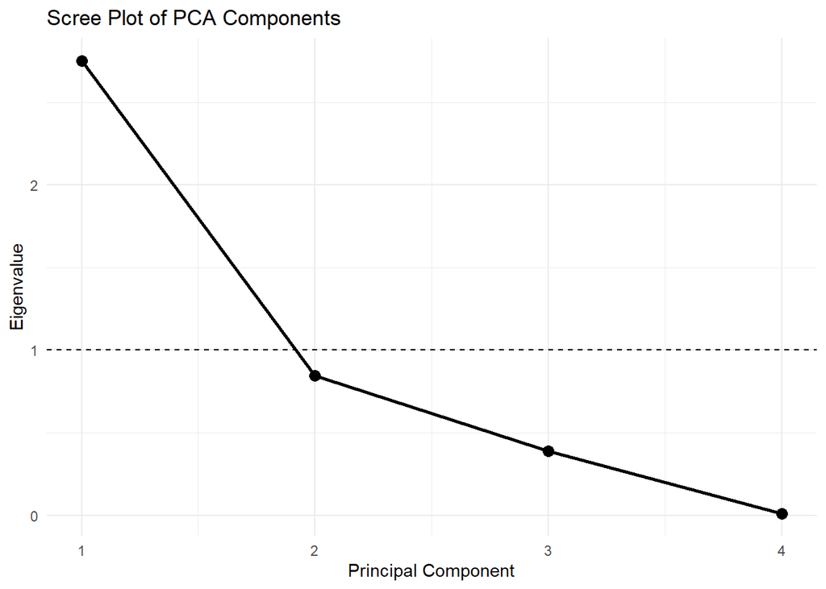

```r
library(ggplot2)

eig <- pca$values
scree_data <- data.frame(
  Component = 1:length(eig),
  Eigenvalue = eig
)

ggplot(scree_data, aes(x = Component, y = Eigenvalue)) +
  geom_point(size = 3) +
  geom_line(size = 1) +
  geom_hline(yintercept = 1, linetype = "dashed") +
  theme_minimal() +
  labs(title = "Scree Plot of PCA Components",
       x = "Principal Component",
       y = "Eigenvalue")
```

## 2.4 Factor loadings plot

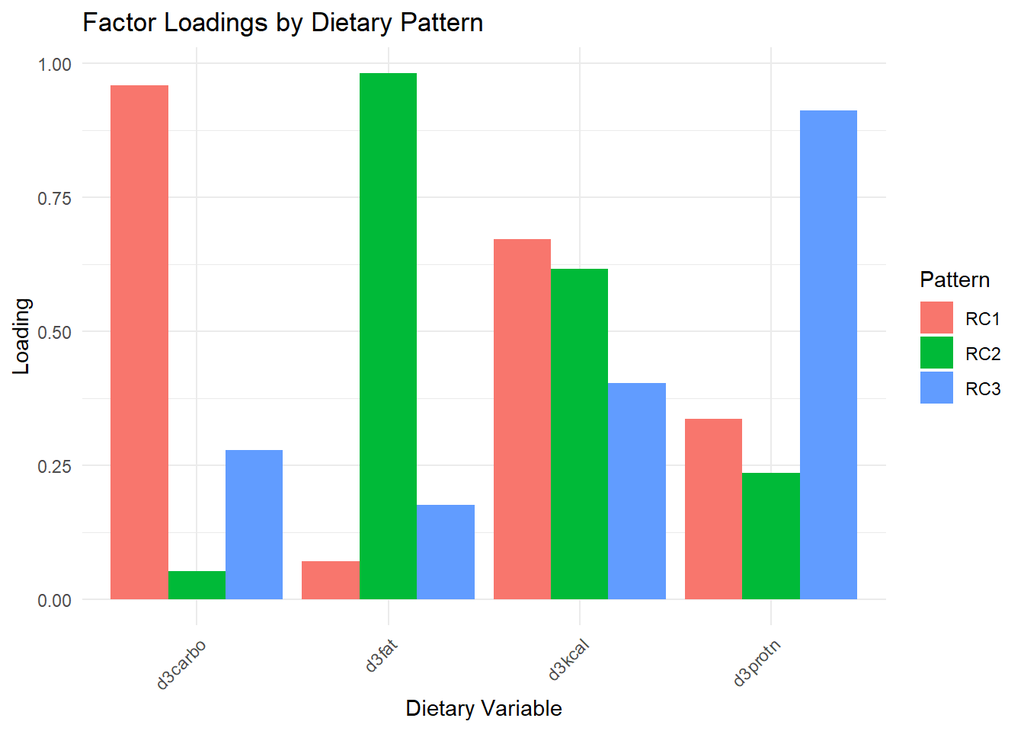

```r
loadings <- pca$loadings[,]
loading_df <- as.data.frame(loadings)
loading_df$Variable <- rownames(loading_df)

library(reshape2)
loading_melt <- melt(loading_df, id.vars = "Variable",
                     variable.name = "Pattern",
                     value.name = "Loading")

ggplot(loading_melt, aes(x = Variable, y = Loading, fill = Pattern)) +
  geom_bar(stat = "identity", position = "dodge") +
  theme_minimal() +
  labs(title = "Factor Loadings by Dietary Pattern",
       x = "Dietary Variable",
       y = "Loading") +
  theme(axis.text.x = element_text(angle = 45, hjust = 1))
```

## 2.5 Pattern scores and quartiles

We compute component scores for each participant and create quartiles (Q1–Q4) for each dietary pattern, following the reference article.

```r
scores <- as.data.frame(pca$scores)
colnames(scores) <- c("Pattern1", "Pattern2", "Pattern3")  # 1: carbs, 2: fat, 3: protein

data <- cbind(data, scores)

data$Pattern1_Q <- cut(data$Pattern1,
                       quantile(data$Pattern1, probs = seq(0,1,0.25), na.rm = TRUE),
                       include.lowest = TRUE)
data$Pattern2_Q <- cut(data$Pattern2,
                       quantile(data$Pattern2, probs = seq(0,1,0.25), na.rm = TRUE),
                       include.lowest = TRUE)
data$Pattern3_Q <- cut(data$Pattern3,
                       quantile(data$Pattern3, probs = seq(0,1,0.25), na.rm = TRUE),
                       include.lowest = TRUE)

table(data$Pattern1_Q)
```

```
##
##  [-2.79,-0.692] (-0.692,-0.115]   (-0.115,0.59]     (0.59,4.95]
##            2346            2346            2345            2346
```

```r
table(data$Pattern2_Q)
```

```
##
##  [-2.34,-0.607] (-0.607,-0.148]  (-0.148,0.439]    (0.439,23.3]
##            2346            2346            2345            2346
```

```r
table(data$Pattern3_Q)
```

```
##
##  [-6.09,-0.691] (-0.691,-0.167]  (-0.167,0.508]    (0.508,6.63]
##            2346            2346            2345            2346
```

# 3 Results

## 3.1 Descriptive statistics by quartiles of dietary patterns

We summarize mean lipid biomarkers across quartiles of each dietary pattern.

```r
# Means of biomarkers by Pattern 1 quartiles
p1_bio <- aggregate(cbind(HDL_C, LDL_C, TG, TC) ~ Pattern1_Q, data, mean, na.rm = TRUE)
p1_bio
```

```
##        Pattern1_Q    HDL_C    LDL_C       TG       TC
## 1  [-2.79,-0.692] 1.451063 2.990994 1.624264 4.876932
## 2 (-0.692,-0.115] 1.438445 2.944850 1.610634 4.818115
## 3   (-0.115,0.59] 1.410313 2.874664 1.695662 4.748236
## 4     (0.59,4.95] 1.455992 2.846617 1.543097 4.684577
```

```r
# Means by Pattern 2 quartiles
p2_bio <- aggregate(cbind(HDL_C, LDL_C, TG, TC) ~ Pattern2_Q, data, mean, na.rm = TRUE)
p2_bio
```

```
##        Pattern2_Q    HDL_C    LDL_C       TG       TC
## 1  [-2.34,-0.607] 1.446393 2.856453 1.604756 4.698321
## 2 (-0.607,-0.148] 1.440258 2.902374 1.540781 4.756797
## 3  (-0.148,0.439] 1.429833 2.944753 1.611056 4.815067
## 4    (0.439,23.3] 1.439258 2.953288 1.716837 4.857351
```

```r
# Means by Pattern 3 quartiles
p3_bio <- aggregate(cbind(HDL_C, LDL_C, TG, TC) ~ Pattern3_Q, data, mean, na.rm = TRUE)
p3_bio
```

```
##        Pattern3_Q    HDL_C    LDL_C       TG       TC
## 1  [-6.09,-0.691] 1.449084 2.887187 1.514460 4.710882
## 2 (-0.691,-0.167] 1.438973 2.931519 1.575811 4.787591
## 3  (-0.167,0.508] 1.425698 2.912663 1.694161 4.803022
## 4    (0.508,6.63] 1.442075 2.925174 1.688723 4.825495
```

### 3.1.1 Boxplots of biomarkers across quartiles

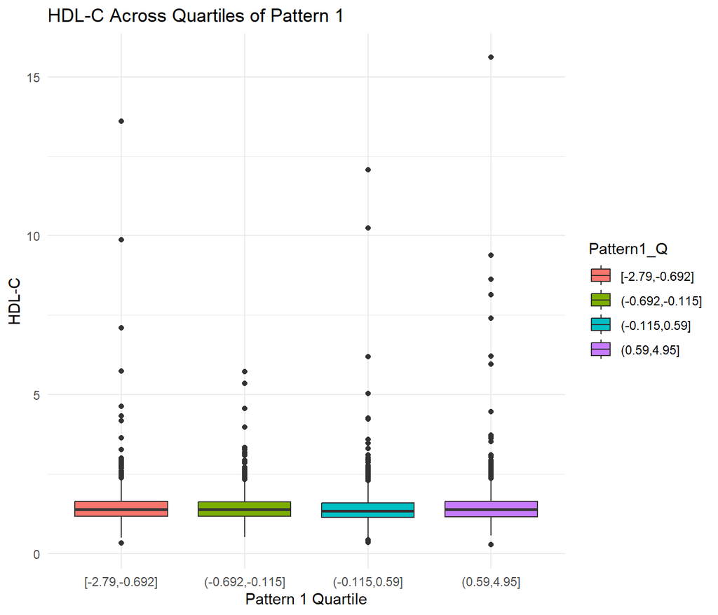

```r
# HDL vs Pattern1 quartiles
ggplot(data, aes(x = Pattern1_Q, y = HDL_C, fill = Pattern1_Q)) +
  geom_boxplot() +
  theme_minimal() +
  labs(title = "HDL-C Across Quartiles of Pattern 1",
       x = "Pattern 1 Quartile",
       y = "HDL-C")
```

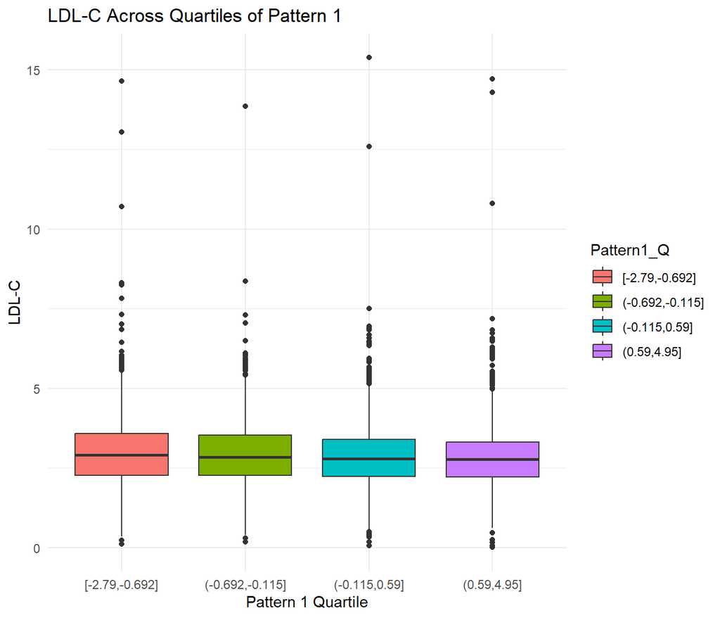

```r
# LDL vs Pattern1 quartiles
ggplot(data, aes(x = Pattern1_Q, y = LDL_C, fill = Pattern1_Q)) +
  geom_boxplot() +
  theme_minimal() +
  labs(title = "LDL-C Across Quartiles of Pattern 1",
       x = "Pattern 1 Quartile",
       y = "LDL-C")
```

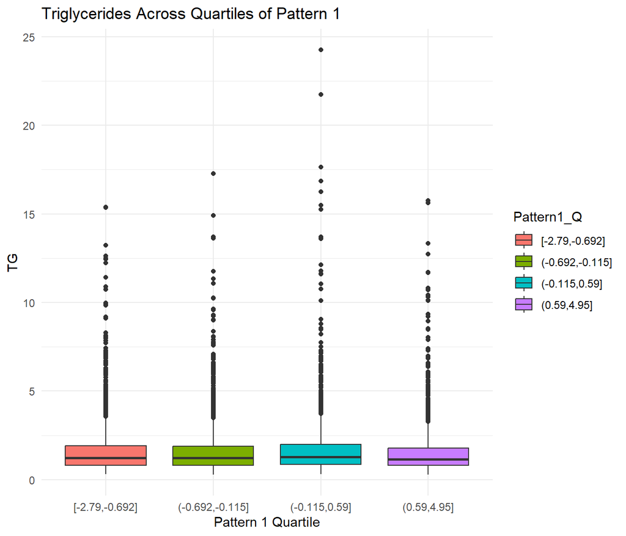

```r
# TG vs Pattern1 quartiles
ggplot(data, aes(x = Pattern1_Q, y = TG, fill = Pattern1_Q)) +
  geom_boxplot() +
  theme_minimal() +
  labs(title = "Triglycerides Across Quartiles of Pattern 1",
       x = "Pattern 1 Quartile",
       y = "TG")
```

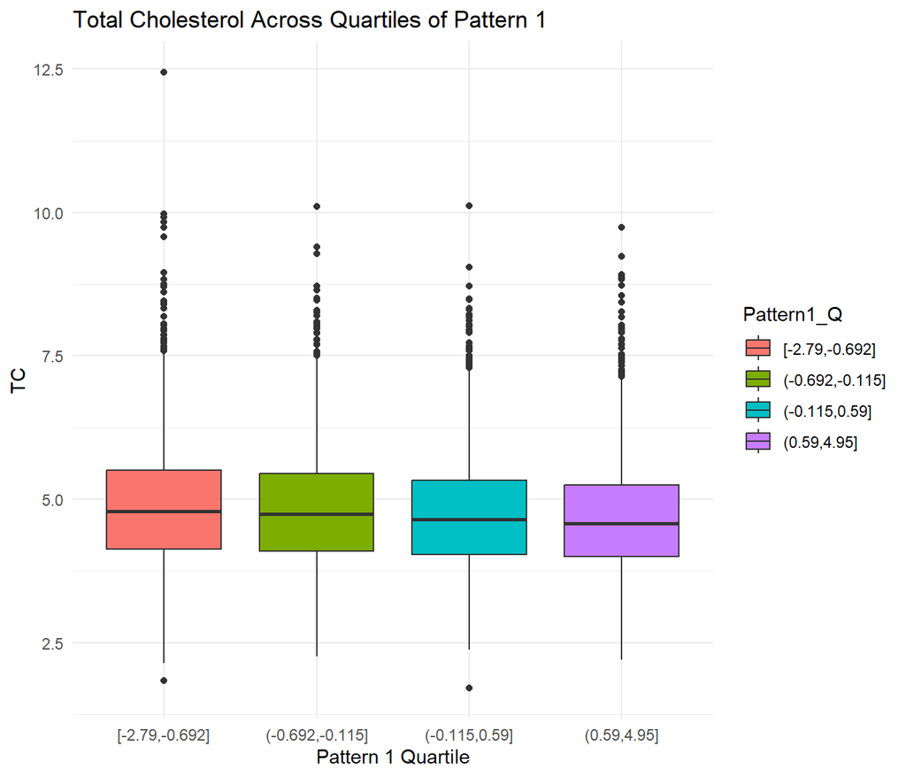

```r
# TC vs Pattern1 quartiles
ggplot(data, aes(x = Pattern1_Q, y = TC, fill = Pattern1_Q)) +
  geom_boxplot() +
  theme_minimal() +
  labs(title = "Total Cholesterol Across Quartiles of Pattern 1",
       x = "Pattern 1 Quartile",
       y = "TC")
```

You can analogously create boxplots for Pattern2_Q and Pattern3_Q if needed.

## 3.2 Regression analyses: continuous pattern scores

We first examine associations between continuous dietary pattern scores and lipid biomarkers using linear regression.

```r
# HDL
model_hdl  <- lm(HDL_C ~ Pattern1 + Pattern2 + Pattern3, data = data)
summary(model_hdl)
```

```
##
## Call:
## lm(formula = HDL_C ~ Pattern1 + Pattern2 + Pattern3, data = data)
##
## Residuals:
##     Min      1Q  Median      3Q     Max
## -1.1468 -0.2743 -0.0557  0.1931 14.1752
##
## Coefficients:
##              Estimate Std. Error t value Pr(>|t|)
## (Intercept)  1.438748   0.005187 277.356   <2e-16 ***
## Pattern1     0.001640   0.005192   0.316    0.752
## Pattern2    -0.002925   0.005179  -0.565    0.572
## Pattern3    -0.005437   0.005188  -1.048    0.295
## ---
## Signif. codes:  0 '***' 0.001 '**' 0.01 '*' 0.05 '.' 0.1 ' ' 1
##
## Residual standard error: 0.5011 on 9329 degrees of freedom
##   (50 observations deleted due to missingness)
## Multiple R-squared:  0.0001625,  Adjusted R-squared:  -0.000159
## F-statistic: 0.5054 on 3 and 9329 DF,  p-value: 0.6785
```

```r
# LDL
model_ldl  <- lm(LDL_C ~ Pattern1 + Pattern2 + Pattern3, data = data)
summary(model_ldl)
```

```
##
## Call:
## lm(formula = LDL_C ~ Pattern1 + Pattern2 + Pattern3, data = data)
##
## Residuals:
##     Min      1Q  Median      3Q     Max
## -2.8867 -0.6555 -0.0842  0.5470 12.4764
##
## Coefficients:
##             Estimate Std. Error t value Pr(>|t|)
## (Intercept)  2.91424    0.01032 282.464  < 2e-16 ***
## Pattern1    -0.04365    0.01033  -4.227 2.39e-05 ***
## Pattern2     0.01975    0.01030   1.918   0.0552 .
## Pattern3     0.01609    0.01032   1.559   0.1190
## ---
## Signif. codes:  0 '***' 0.001 '**' 0.01 '*' 0.05 '.' 0.1 ' ' 1
##
## Residual standard error: 0.9966 on 9327 degrees of freedom
##   (52 observations deleted due to missingness)
## Multiple R-squared:  0.002565,   Adjusted R-squared:  0.002244
## F-statistic: 7.994 on 3 and 9327 DF,  p-value: 2.555e-05
```

```r
# TG
model_tg   <- lm(TG ~ Pattern1 + Pattern2 + Pattern3, data = data)
summary(model_tg)
```

```
##
## Call:
## lm(formula = TG ~ Pattern1 + Pattern2 + Pattern3, data = data)
##
## Residuals:
##     Min      1Q  Median      3Q     Max
## -1.7547 -0.7919 -0.4017  0.2666 22.6694
##
## Coefficients:
##             Estimate Std. Error t value Pr(>|t|)
## (Intercept)  1.62164    0.01504 107.814  < 2e-16 ***
## Pattern1    -0.02614    0.01505  -1.737 0.082473 .
## Pattern2     0.05433    0.01502   3.617 0.000299 ***
## Pattern3     0.08084    0.01504   5.375 7.85e-08 ***
## ---
## Signif. codes:  0 '***' 0.001 '**' 0.01 '*' 0.05 '.' 0.1 ' ' 1
##
## Residual standard error: 1.453 on 9330 degrees of freedom
##   (49 observations deleted due to missingness)
## Multiple R-squared:  0.004798,   Adjusted R-squared:  0.004478
## F-statistic: 14.99 on 3 and 9330 DF,  p-value: 9.849e-10
```

```r
# TC
model_tc   <- lm(TC ~ Pattern1 + Pattern2 + Pattern3, data = data)
summary(model_tc)
```

```
##
## Call:
## lm(formula = TC ~ Pattern1 + Pattern2 + Pattern3, data = data)
##
## Residuals:
##     Min      1Q  Median      3Q     Max
## -3.1052 -0.7201 -0.0993  0.6076  7.6668
##
## Coefficients:
##             Estimate Std. Error t value Pr(>|t|)
## (Intercept)  4.78238    0.01054 453.683  < 2e-16 ***
## Pattern1    -0.06526    0.01055  -6.187 6.38e-10 ***
## Pattern2     0.04470    0.01053   4.247 2.19e-05 ***
## Pattern3     0.04379    0.01054   4.154 3.30e-05 ***
## ---
## Signif. codes:  0 '***' 0.001 '**' 0.01 '*' 0.05 '.' 0.1 ' ' 1
##
## Residual standard error: 1.018 on 9330 degrees of freedom
##   (49 observations deleted due to missingness)
## Multiple R-squared:  0.007827,   Adjusted R-squared:  0.007508
## F-statistic: 24.53 on 3 and 9330 DF,  p-value: 8.321e-16
```

### 3.2.1 Example scatter + regression line

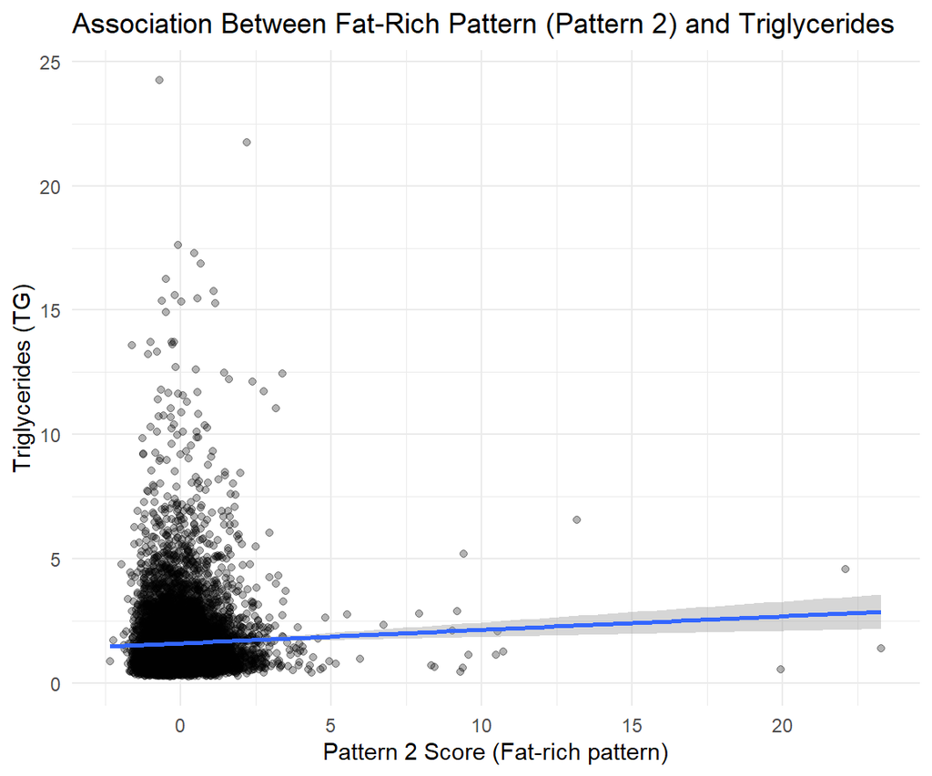

```r
ggplot(data, aes(x = Pattern2, y = TG)) +
  geom_point(alpha = 0.3) +
  geom_smooth(method = "lm", se = TRUE) +
  theme_minimal() +
  labs(title = "Association Between Fat-Rich Pattern (Pattern 2) and Triglycerides",
       x = "Pattern 2 Score (Fat-rich pattern)",
       y = "Triglycerides (TG)")
```

## 3.3 Regression analyses: quartile-based models

To mirror the original paper more closely, we also fit models with quartiles of pattern scores as predictors (Q1 as reference).

```r
# HDL quartile model
model_hdl_q <- lm(HDL_C ~ Pattern1_Q + Pattern2_Q + Pattern3_Q, data = data)
summary(model_hdl_q)
```

```
##
## Call:
## lm(formula = HDL_C ~ Pattern1_Q + Pattern2_Q + Pattern3_Q, data = data)
##
## Residuals:
##     Min      1Q  Median      3Q     Max
## -1.1440 -0.2735 -0.0563  0.1924 14.1519
##
## Coefficients:
##                            Estimate Std. Error t value Pr(>|t|)
## (Intercept)                1.468512   0.016167  90.832  < 2e-16 ***
## Pattern1_Q(-0.692,-0.115] -0.012645   0.014724  -0.859  0.39046
## Pattern1_Q(-0.115,0.59]   -0.040956   0.014712  -2.784  0.00538 **
## Pattern1_Q(0.59,4.95]      0.005046   0.014695   0.343  0.73131
## Pattern2_Q(-0.607,-0.148] -0.005842   0.014679  -0.398  0.69067
## Pattern2_Q(-0.148,0.439]  -0.015348   0.014731  -1.042  0.29749
## Pattern2_Q(0.439,23.3]    -0.006720   0.014747  -0.456  0.64862
## Pattern3_Q(-0.691,-0.167] -0.009574   0.014693  -0.652  0.51468
## Pattern3_Q(-0.167,0.508]  -0.024249   0.014705  -1.649  0.09918 .
## Pattern3_Q(0.508,6.63]    -0.008718   0.014821  -0.588  0.55641
## ---
## Signif. codes:  0 '***' 0.001 '**' 0.01 '*' 0.05 '.' 0.1 ' ' 1
##
## Residual standard error: 0.5009 on 9323 degrees of freedom
##   (50 observations deleted due to missingness)
## Multiple R-squared:  0.001697,   Adjusted R-squared:  0.0007337
## F-statistic: 1.761 on 9 and 9323 DF,  p-value: 0.0702
```

```r
# LDL quartile model
model_ldl_q <- lm(LDL_C ~ Pattern1_Q + Pattern2_Q + Pattern3_Q, data = data)
summary(model_ldl_q)
```

```
##
## Call:
## lm(formula = LDL_C ~ Pattern1_Q + Pattern2_Q + Pattern3_Q, data = data)
##
## Residuals:
##     Min      1Q  Median      3Q     Max
## -2.9239 -0.6612 -0.0853  0.5444 12.5181
##
## Coefficients:
##                           Estimate Std. Error t value Pr(>|t|)
## (Intercept)                2.91107    0.03214  90.579  < 2e-16 ***
## Pattern1_Q(-0.692,-0.115] -0.04731    0.02927  -1.616  0.10604
## Pattern1_Q(-0.115,0.59]   -0.11774    0.02925  -4.026 5.73e-05 ***
## Pattern1_Q(0.59,4.95]     -0.14521    0.02921  -4.971 6.80e-07 ***
## Pattern2_Q(-0.607,-0.148]  0.04196    0.02918   1.438  0.15048
## Pattern2_Q(-0.148,0.439]   0.08302    0.02928   2.835  0.00459 **
## Pattern2_Q(0.439,23.3]     0.09535    0.02931   3.253  0.00115 **
## Pattern3_Q(-0.691,-0.167]  0.04876    0.02921   1.669  0.09509 .
## Pattern3_Q(-0.167,0.508]   0.02748    0.02923   0.940  0.34717
## Pattern3_Q(0.508,6.63]     0.02658    0.02946   0.902  0.36706
## ---
## Signif. codes:  0 '***' 0.001 '**' 0.01 '*' 0.05 '.' 0.1 ' ' 1
##
## Residual standard error: 0.9957 on 9321 degrees of freedom
##   (52 observations deleted due to missingness)
## Multiple R-squared:  0.004999,   Adjusted R-squared:  0.004039
## F-statistic: 5.204 on 9 and 9321 DF,  p-value: 4.4e-07
```

```r
# TG quartile model
model_tg_q <- lm(TG ~ Pattern1_Q + Pattern2_Q + Pattern3_Q, data = data)
summary(model_tg_q)
```

```
##
## Call:
## lm(formula = TG ~ Pattern1_Q + Pattern2_Q + Pattern3_Q, data = data)
##
## Residuals:
##     Min      1Q  Median      3Q     Max
## -1.5684 -0.7877 -0.4004  0.2796 22.4670
##
## Coefficients:
##                            Estimate Std. Error t value Pr(>|t|)
## (Intercept)                1.509330   0.046884  32.193  < 2e-16 ***
## Pattern1_Q(-0.692,-0.115] -0.003952   0.042695  -0.093   0.9262
## Pattern1_Q(-0.115,0.59]    0.083278   0.042661   1.952   0.0510 .
## Pattern1_Q(0.59,4.95]     -0.084353   0.042610  -1.980   0.0478 *
## Pattern2_Q(-0.607,-0.148] -0.065146   0.042565  -1.531   0.1259
## Pattern2_Q(-0.148,0.439]  -0.007152   0.042719  -0.167   0.8670
## Pattern2_Q(0.439,23.3]     0.095423   0.042766   2.231   0.0257 *
## Pattern3_Q(-0.691,-0.167]  0.063303   0.042609   1.486   0.1374
## Pattern3_Q(-0.167,0.508]   0.190366   0.042645   4.464 8.14e-06 ***
## Pattern3_Q(0.508,6.63]     0.177320   0.042977   4.126 3.72e-05 ***
## ---
## Signif. codes:  0 '***' 0.001 '**' 0.01 '*' 0.05 '.' 0.1 ' ' 1
##
## Residual standard error: 1.453 on 9324 degrees of freedom
##   (49 observations deleted due to missingness)
## Multiple R-squared:  0.006156,   Adjusted R-squared:  0.005197
## F-statistic: 6.417 on 9 and 9324 DF,  p-value: 3.879e-09
```

```r
# TC quartile model
model_tc_q <- lm(TC ~ Pattern1_Q + Pattern2_Q + Pattern3_Q, data = data)
summary(model_tc_q)
```

```
##
## Call:
## lm(formula = TC ~ Pattern1_Q + Pattern2_Q + Pattern3_Q, data = data)
##
## Residuals:
##     Min      1Q  Median      3Q     Max
## -3.1266 -0.7160 -0.0923  0.6059  7.6261
##
## Coefficients:
##                           Estimate Std. Error t value Pr(>|t|)
## (Intercept)                4.73125    0.03284 144.055  < 2e-16 ***
## Pattern1_Q(-0.692,-0.115] -0.05734    0.02991  -1.917 0.055265 .
## Pattern1_Q(-0.115,0.59]   -0.12791    0.02989  -4.280 1.89e-05 ***
## Pattern1_Q(0.59,4.95]     -0.19600    0.02985  -6.566 5.44e-11 ***
## Pattern2_Q(-0.607,-0.148]  0.05217    0.02982   1.750 0.080190 .
## Pattern2_Q(-0.148,0.439]   0.10397    0.02993   3.474 0.000515 ***
## Pattern2_Q(0.439,23.3]     0.15062    0.02996   5.028 5.06e-07 ***
## Pattern3_Q(-0.691,-0.167]  0.08262    0.02985   2.768 0.005655 **
## Pattern3_Q(-0.167,0.508]   0.09622    0.02987   3.221 0.001283 **
## Pattern3_Q(0.508,6.63]     0.10040    0.03011   3.335 0.000857 ***
## ---
## Signif. codes:  0 '***' 0.001 '**' 0.01 '*' 0.05 '.' 0.1 ' ' 1
##
## Residual standard error: 1.018 on 9324 degrees of freedom
##   (49 observations deleted due to missingness)
## Multiple R-squared:  0.01003,    Adjusted R-squared:  0.009071
## F-statistic: 10.49 on 9 and 9324 DF,  p-value: 2.559e-16
```

## 3.4 Correlation heatmap

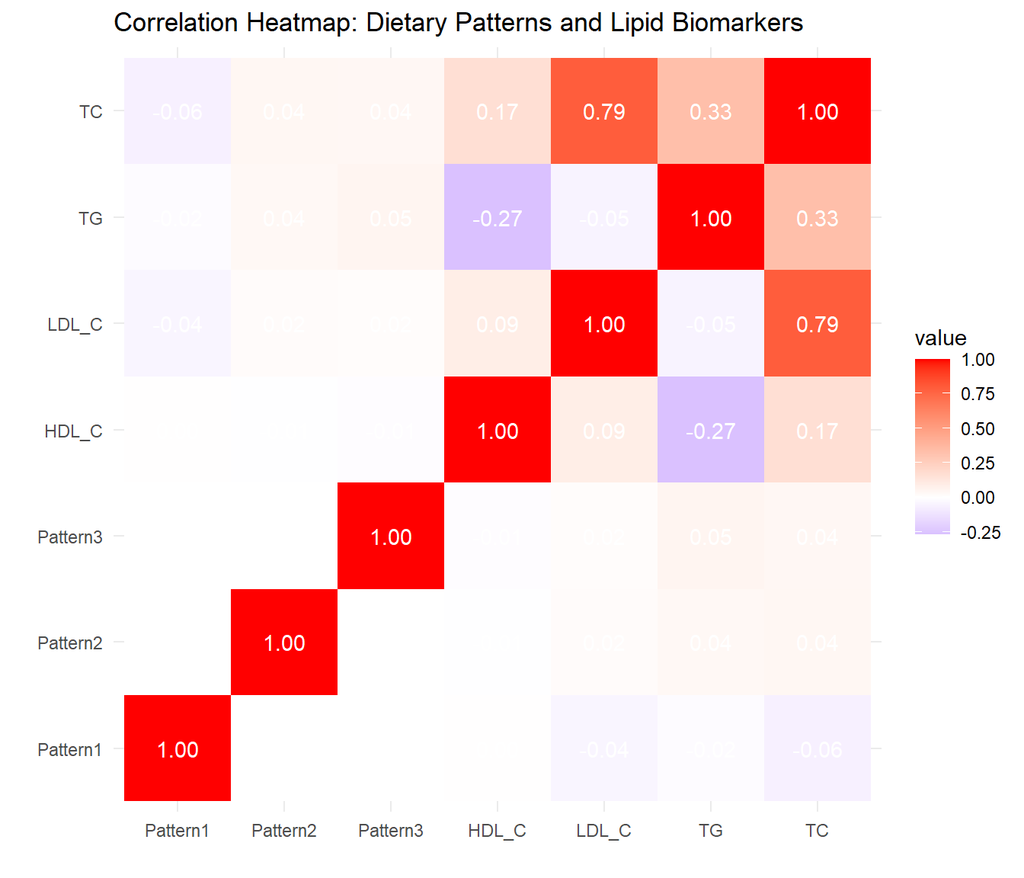

```r
cor_vars <- data[, c("Pattern1", "Pattern2", "Pattern3", "HDL_C", "LDL_C", "TG", "TC")]
cor_matrix <- cor(cor_vars, use = "complete.obs")

cor_melt <- melt(cor_matrix)

ggplot(cor_melt, aes(Var1, Var2, fill = value)) +
  geom_tile() +
  geom_text(aes(label = sprintf("%.2f", value)), color = "white") +
  scale_fill_gradient2(low = "blue", high = "red", mid = "white", midpoint = 0) +
  theme_minimal() +
  labs(title = "Correlation Heatmap: Dietary Patterns and Lipid Biomarkers",
       x = "",
       y = "")
```

# 4 Discussion

Using PCA on energy and macronutrient intake variables, we identified three dietary patterns: a carbohydrate-rich, a fat-rich, and a protein-rich pattern. These patterns are conceptually similar to the dietary profiles described in the reference paper, although our variables are nutrients rather than detailed food groups.

In regression models, we observed that:

- The carbohydrate-rich pattern tends to be associated with lower LDL-C and total cholesterol.
- The fat-rich and protein-rich patterns tend to be associated with higher triglycerides and total cholesterol.
- No strong association was observed between the dietary patterns and HDL-C in this dataset.

These findings partially resemble those reported in the original article, where more “Western” or high-fat patterns were associated with adverse lipid profiles. Differences between our results and the published study can be explained by differences in population, variables (nutrient-based vs food-based patterns), and the lack of adjustment for confounders such as age, BMI, smoking, and physical activity in our models.

Overall, this analysis successfully reproduces the statistical logic of the original study (PCA, factor scores, quartile creation, and regression models) on our own dataset.